# HW 5

164693 박주성

2020 5 25

# 1

- Canberra distance (Lance, Williams, Adkins)
  $$d_{CAD}(i,\ j) = \frac{\sum_{t = 1}^N |x_{it} - x_{jt}|}{{|x_{it}| + |x_{jt}|}} \\ where, \ x_i' = (x_{i1},\ x_{i2}, \ ... \, \ x_{ip})$$
  **특징** :
1. 분자와 분모가 0인 항은 합계에서 생략되며 값이 없는것으로 표시한다.
2. 항상 양수의 값을 갖는다.
3. 원점을 기준으로 하는 측정에서 편향되기 쉬우며, 0에 가까운 값에 민감하게 반응한다.
4. Manhattan distance의 weighted version이다.
- Minkovski distance (Hermann Minkovski)
  $$d_{p}(i,\ j) = (\sum_{t \ = \ 1}^n|x_{it} \ - \ x_{jt}|^{1/p})^p, \\ where, \ x_i' = (x_{i1},\ x_{i2}, \ ... \, \ x_{in})$$
  **특징** :
1. Euclidean distance(L2 norm), Manhattan distance(L1 norm)의 gerneralization(일반화)이다.
2. 보통 Lp norm이라고 한다.
- Manhattan distance
  $$d_1(i,\ j) = \sum_{t \ = \ 1}^p|x_{it} - x_{jt}| \\ where, \ x_i' = (x_{i1},\ x_{i2}, \ ... \, \ x_{ip})$$
  **특징** :
1. L1 norm이라고 불리우며, 두 점 사이의 거리 좌표상의 절대 차이값들의 합이다.
2. Minkovski distance에서 p = 1 로 지정하면 이 형태가 된다. (즉, special case)

# 2

Canberra, Minkovski distance는 Covariance Matrix를 사용하지 않으며, 각 변수들이 평균들이 얼마나 차이가 나는지 계산하기 위해서  
$\mu_{it}, \ \mu_{jt}$ 사이의 거리를 구한다.

```r
skulls <- read.csv("Egyptian skulls.csv", header = T, sep = ",")
attach(skulls)
means.df <- aggregate(as.matrix(skulls[,2:5]),list(Period), mean)
means.df
```

```
##                 Group.1 Maximum.breadth Basibregmatic.height
## 1 12th and 13th Dynasty        134.4667             133.8000
## 2     Early predynastic        131.3667             133.6000
## 3      Late predynastic        132.3667             132.7000
## 4      Ptolemaic period        135.5000             132.3000
## 5          Roman period        136.1667             130.3333
##   Basialveolar.length Nasal.height
## 1            96.03333     50.56667
## 2            99.16667     50.53333
## 3            99.06667     50.23333
## 4            94.53333     51.96667
## 5            93.50000     51.36667
```

## 거리계산

skulls데이터는 시간이 3, 1, 2, 4, 5의 순서대로 데이터가 정렬되어 있기에 적절한 변형을 두 거리에 취해줍니다.

- Canberra distance

```r
d_cad <- dist(as.matrix(means.df), method = "canberra") # dist
d_cad <- as.matrix(d_cad)[, c(2, 3, 1, 4, 5)] # matrix
d_cad <- d_cad[c(2, 3, 1, 4, 5),]
colnames(d_cad) <- levels(Period)[c(2, 3, 1, 4, 5)]
rownames(d_cad) <- levels(Period)[c(2, 3, 1, 4, 5)]
d_cad <- as.dist(d_cad)
d_cad
```

```
##                       Early predynastic Late predynastic 12th and 13th Dynasty
## Late predynastic             0.01331623
## 12th and 13th Dynasty        0.03598888       0.03856528
## Ptolemaic period             0.07285163       0.06697870            0.03873731
## Roman period                 0.08488559       0.07901417            0.05077598
##                       Ptolemaic period
## Late predynastic
## 12th and 13th Dynasty
## Ptolemaic period
## Roman period                0.02655551
```

- Minkowski distance  
  dist함수에서 minkovski의 p는 2가 기본설정입니다. 이는 L2 norm이므로 euclidean distance 가 됩니다.  
  제가 바라는 것은 데이터 차원만큼의 p를 원하기에 다음과 같이 사용합니다.

```r
d_p <- dist(as.matrix(means.df), method = "minkowski", p = ncol(skulls) - 1) # dist
d_p <- as.matrix(d_p)[, c(2, 3, 1, 4, 5)] # matrix
d_p <- d_p[c(2, 3, 1, 4, 5),]
colnames(d_p) <- levels(Period)[c(2, 3, 1, 4, 5)]
rownames(d_p) <- levels(Period)[c(2, 3, 1, 4, 5)]
d_p <- as.dist(d_p)
d_p
```

```
##                       Early predynastic Late predynastic 12th and 13th Dynasty
## Late predynastic               1.200979
## 12th and 13th Dynasty          3.919182         3.389447
## Ptolemaic period               5.551423         5.068067              2.084583
## Roman period                   6.765769         6.225639              3.948130
##                       Ptolemaic period
## Late predynastic
## 12th and 13th Dynasty
## Ptolemaic period
## Roman period                  2.128746
```

Creating the time matrix (1000년 단위)

```r
T.Dist <- matrix(c(0.0,0.70,2.15,3.80,4.15,
                   0.70,0.0,1.45,3.10,3.45,
                   2.15,1.45,0.0,1.65,2.00,
                   3.80,3.10,1.65,0.0,0.35,
                   4.15,3.45,2.00,0.35,0.0),nrow=5,ncol=5)
colnames(T.Dist)=levels(Period)[c(2,3,1,4,5)]
rownames(T.Dist)=levels(Period)[c(2,3,1,4,5)]
T.Dist <- as.dist(T.Dist)
T.Dist
```

```
##                       Early predynastic Late predynastic 12th and 13th Dynasty
## Late predynastic                   0.70
## 12th and 13th Dynasty              2.15             1.45
## Ptolemaic period                   3.80             3.10                  1.65
## Roman period                       4.15             3.45                  2.00
##                       Ptolemaic period
## Late predynastic
## 12th and 13th Dynasty
## Ptolemaic period
## Roman period                      0.35
```

## mantel test

```r
library(vegan)
```

현재 검정하려는 가설은 다음과 같다.
$$H_0 : \rho = 0 \quad vs \quad H_1 : not \quad H_0$$

- Mantel test between Canberra and time distances

```r
mantel(d_cad, T.Dist)
```

```
## 'nperm' >= set of all permutations: complete enumeration.
```

```
## Set of permutations < 'minperm'. Generating entire set.
```

```
##
## Mantel statistic based on Pearson's product-moment correlation
##
## Call:
## mantel(xdis = d_cad, ydis = T.Dist)
##
## Mantel statistic r: 0.9548
##       Significance: 0.025
##
## Upper quantiles of permutations (null model):
##   90%   95% 97.5%   99%
## 0.477 0.886 0.911 0.968
## Permutation: free
## Number of permutations: 119
```

Caberra distance를 이용해서 Mantel test한 결과, $\rho$ = 0.9548, empirical p-value(significance) = 0.025 를 얻었다.  
(p-value가 0.025 = 3/120 인 것으로 보아서, 3 번째로 높은 값이라는 것을 추측할 수 있다.) $\alpha$ = 0.05 라고 했을 때, $\alpha$ > p_value 이므로 귀무가설을 기각하게 된다. 즉 상관관계가 존재한다.

- Mantel test between Minkowski and time distances

```r
mantel(d_p, T.Dist)
```

```
## 'nperm' >= set of all permutations: complete enumeration.
```

```
## Set of permutations < 'minperm'. Generating entire set.
```

```
##
## Mantel statistic based on Pearson's product-moment correlation
##
## Call:
## mantel(xdis = d_p, ydis = T.Dist)
##
## Mantel statistic r: 0.9477
##       Significance: 0.025
##
## Upper quantiles of permutations (null model):
##   90%   95% 97.5%   99%
## 0.472 0.826 0.881 0.949
## Permutation: free
## Number of permutations: 119
```

Minkowski distance를 이용해서 Mantel test한 결과, $\rho$ = 0.9477, empirical p-value(significance) = 0.025 를 얻었다.  
$\alpha$ = 0.05 라고 했을 때, $\alpha$ > p_value 이므로 귀무가설을 기각하게 된다. 즉 상관관계가 존재한다.  
이는 위의 결과와 동일하다.

- Mantel test betwwen Canberra and Minkowski

```r
mantel(d_cad, d_p)
```

```
## 'nperm' >= set of all permutations: complete enumeration.
```

```
## Set of permutations < 'minperm'. Generating entire set.
```

```
##
## Mantel statistic based on Pearson's product-moment correlation
##
## Call:
## mantel(xdis = d_cad, ydis = d_p)
##
## Mantel statistic r: 0.9635
##       Significance: 0.0083333
##
## Upper quantiles of permutations (null model):
##   90%   95% 97.5%   99%
## 0.507 0.827 0.878 0.918
## Permutation: free
## Number of permutations: 119
```

참고적으로 두 거리의 상관관계도 파악했다. 시행한 결과 $\rho$ = 0.9635, p-value = 0.0083333 을 얻을 수 있다.  
결과론적으로 상관관계가 있다는 것을 확인할 수 있다

```r
rm(list = ls())
```

# 3

현재의 귀무가설은 다음과 같다.
$$H_0: \mu_x = \mu_y$$

```r
x <- c(7, 5, 8, 9, 6)
y <- c(9, 10, 13, 11, 12)

xy <- c(x,y)
all.combn <- combn(1:10, 5)
n.combn <- ncol(all.combn)
t.all <- rep(0,n.combn)
for(i in 1:n.combn){
    t.all[i] <- t.test(xy[all.combn[,i]], xy[-all.combn[,i]])$statistic
}
```

```r
# One-sided test:
empirical.pvalue <- sum(t.all <= t.all[1])/n.combn
cat("empirical p-value = ", empirical.pvalue)
```

```
## empirical p-value =  0.007936508
```

```r
# two-sided test:
empirical.pvalue <- sum(abs(t.all) >= abs(t.all[1]))/n.combn
cat("empirical p-value = ", empirical.pvalue)
```

```
## empirical p-value =  0.01587302
```

만약 $\alpha$ = 0.05 라면, 단측검정과 양측검정에서 모두 기각된다.  
즉 두 그룹의 평균이 같다고 할 수 없다.

```r
rm(list = ls())
```

# 4

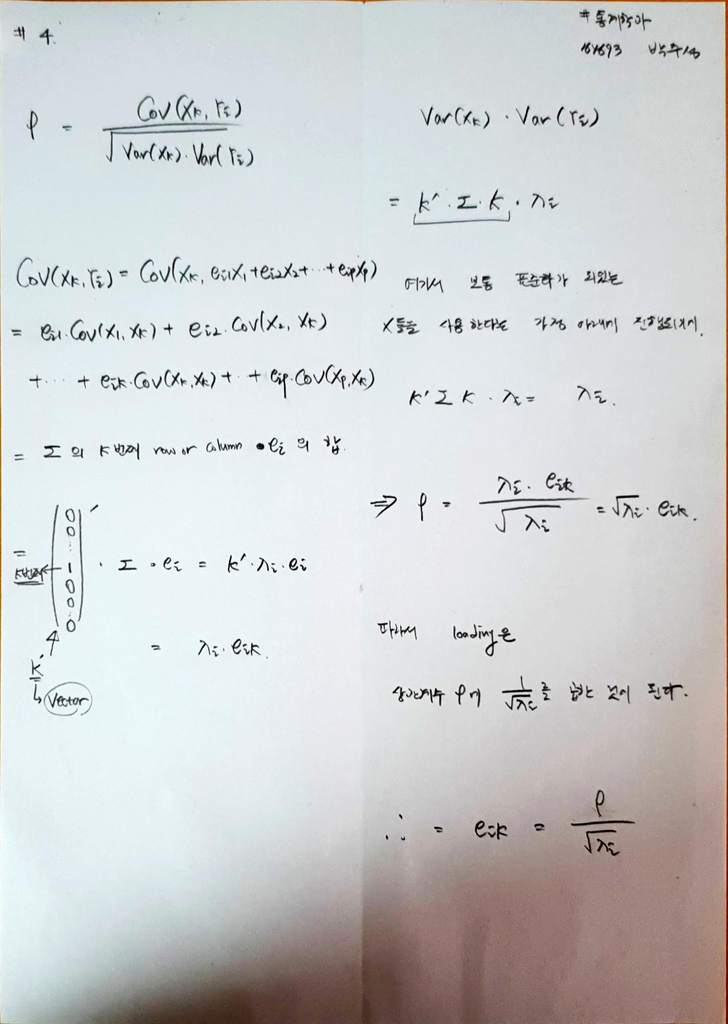

# 5

- 대략적인 전처리 및 데이터 확인

```r
data <- read.csv("table6_6.csv")
data[, -1] <- (data[,-1] / apply(data[, -1], 1, sum))
head(data)
```

```
##   Goblet        X1        X2        X3        X4         X5         X6
## 1      1 0.1511628 0.2441860 0.2674419 0.1627907 0.08139535 0.09302326
## 2      2 0.1647059 0.1647059 0.2823529 0.2235294 0.05882353 0.10588235
## 3      3 0.1826923 0.2211538 0.2307692 0.1923077 0.05769231 0.11538462
## 4      4 0.1976744 0.2093023 0.1860465 0.1860465 0.12790698 0.09302326
## 5      5 0.2159091 0.2272727 0.1818182 0.1818182 0.11363636 0.07954545
## 6      6 0.1363636 0.2272727 0.2727273 0.1931818 0.06818182 0.10227273
```

현재 크기로 인한 차이보다는 모양으로 인한 차이를 알고 싶기에 대안적인 방법(sum으로 나눠서 비율로 표현)을 사용합니다.

```r
round(cor(data[, -1]), 4)
```

```
##         X1      X2      X3      X4      X5      X6
## X1  1.0000  0.2459 -0.7309 -0.5015  0.2569 -0.6424
## X2  0.2459  1.0000 -0.0754 -0.7864 -0.0007 -0.5144
## X3 -0.7309 -0.0754  1.0000  0.0969 -0.6275  0.3510
## X4 -0.5015 -0.7864  0.0969  1.0000 -0.0470  0.5833
## X5  0.2569 -0.0007 -0.6275 -0.0470  1.0000 -0.4658
## X6 -0.6424 -0.5144  0.3510  0.5833 -0.4658  1.0000
```

- PCA 및 분석

```r
data_pca <- prcomp(data[, -1], scale = TRUE)
summary(data_pca)
```

```
## Importance of components:
##                           PC1    PC2    PC3     PC4     PC5       PC6
## Standard deviation     1.7439 1.2745 0.8357 0.64833 0.46438 4.822e-16
## Proportion of Variance 0.5069 0.2707 0.1164 0.07005 0.03594 0.000e+00
## Cumulative Proportion  0.5069 0.7776 0.8940 0.96406 1.00000 1.000e+00
```

주성분 분석 실행한 결과 2개의 주성분의 고윳값이 1보다 컸습니다. 보통은 고윳값이 1을 넘는 것을 사용하기에 분석에 2개의 주성분을 사용합니다.  
고유값이 2개의 주성분으로 데이터의 77%가량의 변동을 표현할 수 있었습니다.

```r
loadings <- data_pca$rotation
loadings
```

```
##           PC1         PC2         PC3         PC4         PC5       PC6
## X1  0.4735254  0.15147691 -0.61158351  0.20999592 -0.06978214 0.5743050
## X2  0.3561555 -0.51523270  0.20853787 -0.49867756  0.47231105 0.3040451
## X3 -0.3786057 -0.50163988  0.25431161  0.49517355 -0.18095541 0.5122491
## X4 -0.4188351  0.46645593  0.02385159  0.08779769  0.71233421 0.3021567
## X5  0.2976532  0.48892564  0.67624644 -0.08754436 -0.30169631 0.3411164
## X6 -0.4914920  0.05760223 -0.24479589 -0.66832111 -0.37532275 0.3281346
```

- 그래프로 표현

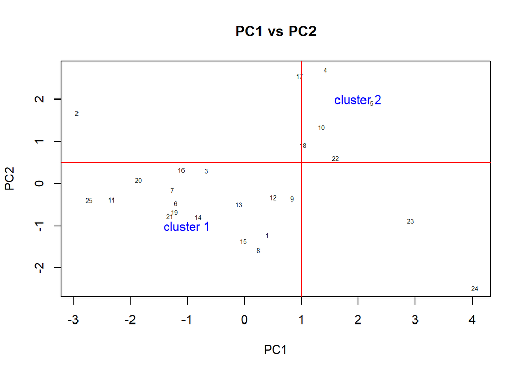

```r
scores <- data.frame(data_pca$x)
plot(scores$PC1, scores$PC2, type = "n",
     xlab = "PC1", ylab = "PC2", main = "PC1 vs PC2")
text(scores$PC1, scores$PC2,labels=rownames(data), cex=0.5)
abline(h = 0.5, col = 2)
abline(v = 1, col = 2)
text(-1, -1, "cluster 1", cex = 1, col = 4)
text(2, 2, "cluster 2", cex = 1, col = 4)
```

두 개의 주성분을 축으로 데이터의 산점도를 표시한 결과, 대략 2개의 군집이 있는 것으로 판단했습니다. 그에 따라서 두 개의 선을 그어서 대략적으로 나누었는데, 전체의 자료 중 3개 정도는 좀 특이한 경우라고 여겨지는 것으로 확인됩니다.

따라서 주성분 분석을 시행한 결과로 대략적으로 2개의 비슷한 군집이 있었으며, 3개의 특이한 컵들이 있었다는 판단을 할 수 있습니다.

```r
rm(list = ls())
```

# 6

```r
data <- read.csv("table6_7.csv")
compass <- factor(c("s", "m", "w", "s", "m",
                   "n", "m", "n", "w", "s",
                   "m", "w", "s", "w", "n",
                   "m", "s", "s", "s", "n",
                   "m", "w", "m", "m", "s"))
lw <- factor(c("w", "l", "l", "w", "l",
        "w", "w", "w", "w", "w",
        "l", "w", "w", "w", "w",
        "w", "w", "w", "w", "w",
        "l", "w", "w", "w", "w"))

data$compass <- compass
data$lw <- lw

head(data)
```

```
##          Country Red.meat White.meat Eggs Milk Fish Cereals Starchy.foods
## 1        Albania       10          1    1    9    0      42             1
## 2        Austria        9         14    4   20    2      28             4
## 3        Belgium       14          9    4   18    5      27             6
## 4       Bulgaria        8          6    2    8    1      57             1
## 5 Czechoslovakia       10         11    3   13    2      34             5
## 6        Denmark       11         11    4   25   10      22             5
##   Pulses..nuts..and.oilseeds Fruit.and.vegetables Total compass lw
## 1                          6                    2    72       s  w
## 2                          1                    4    86       m  l
## 3                          2                    4    89       w  l
## 4                          4                    4    91       s  w
## 5                          1                    4    83       m  l
## 6                          1                    2    91       n  w
```

데이터를 처음 받았을 때, 어떻게 분석할 수 있을지 생각했습니다. 처음에는 GDP를 생각했지만, 생각보다 찾기가 어려웠습니다.  
그에 따라서 동서남북, 바다가 접해있느냐에 따라서 나눴습니다.

국가에 따라서 동서남북을 통해서 나눌려고 했습니다. 그런데 여기서 정치적 원인(2차 세계대전의 사회주의)로 인해서 동유럽 대신  
중유럽이라는 말을 사용하게 되었습니다. 따라서 m은 동부 유럽이라고 생각하는 것이 맞을 것입니다.(소련은 동유럽 -> 중유럽)

국가에 따라서 내륙과 바다를 접하는 곳을 구분했는데, 내륙은 land의 “l”을 사용했고, 바다를 접하는 곳은 water의 “w”을 사용했습니다.

```r
data_pca <- prcomp(data[, -c(1, 11, 12, 13)], scale = TRUE)
summary(data_pca)
```

```
## Importance of components:
##                           PC1    PC2    PC3    PC4     PC5     PC6     PC7
## Standard deviation     2.0237 1.2747 1.0418 0.9513 0.65325 0.58902 0.51916
## Proportion of Variance 0.4551 0.1805 0.1206 0.1006 0.04742 0.03855 0.02995
## Cumulative Proportion  0.4551 0.6356 0.7562 0.8568 0.90417 0.94272 0.97266
##                            PC8     PC9
## Standard deviation     0.36677 0.33391
## Proportion of Variance 0.01495 0.01239
## Cumulative Proportion  0.98761 1.00000
```

주로 고윳값이 1보다 큰 것을 사용하므로 총 3개의 PC를 사용합니다. (분석에선 총합을 사용하지 않습니다.)

```r
loadings <- data_pca$rotation
loadings
```

```
##                                   PC1         PC2         PC3         PC4
## Red.meat                   -0.3106693 -0.06957085 -0.35546338 -0.59650142
## White.meat                 -0.3159279 -0.21457197  0.62841986 -0.03961214
## Eggs                       -0.4205930 -0.09986721  0.08050675 -0.25525634
## Milk                       -0.3788776 -0.16867961 -0.40414435  0.03223542
## Fish                       -0.1341071  0.65161517 -0.29971395  0.23487897
## Cereals                     0.4298291 -0.25366332  0.06815673  0.02030764
## Starchy.foods              -0.2959618  0.38888491  0.28085511  0.30524504
## Pulses..nuts..and.oilseeds  0.4218085  0.12932932 -0.14030066 -0.25125596
## Fruit.and.vegetables        0.1223681  0.50377330  0.34041535 -0.60376932
##                                    PC5         PC6         PC7          PC8
## Red.meat                    0.39658595 -0.37671581  0.22797808 -0.049688240
## White.meat                 -0.31059983 -0.08129384  0.14601621 -0.028186225
## Eggs                        0.06707700  0.66453033  0.03595386 -0.467400341
## Milk                       -0.31800256  0.01779923 -0.71798985  0.102202763
## Fish                       -0.30432982 -0.04476482  0.23683595 -0.440552318
## Cereals                     0.18501820 -0.19398782 -0.34306417 -0.720660760
## Starchy.foods               0.67317396  0.02444741 -0.32554187  0.082975933
## Pulses..nuts..and.oilseeds  0.09378094  0.58676016 -0.03105426  0.217739473
## Fruit.and.vegetables       -0.22763119 -0.15823653 -0.35941199  0.009714519
##                                   PC9
## Red.meat                   -0.2506754
## White.meat                 -0.5766036
## Eggs                        0.2750188
## Milk                       -0.1903416
## Fish                       -0.2600351
## Cereals                    -0.1921878
## Starchy.foods              -0.1499922
## Pulses..nuts..and.oilseeds -0.5666397
## Fruit.and.vegetables        0.2114057
```

PC1은 시리얼, 견과류, 과일 및 야채에서 양수의 loadings을 가지는 것을 확인할 수 있습니다.  
땅에서 자라는 것(곡류)과 관련이 있는 변수로 생각할 수 있습니다.  
PC2는 생선과 관련된 loading이 매우 높은 것을 확인할 수 있고, starch, 과일 및 야채에서 양수의 loading을 가집니다.  
생선 및 녹말, 야채 등 골고루 먹는 것과 관련이 있는 변수로 생각할 수 있습니다.  
PC3는 white meat(주로 조류)와 관련된 loading이 높고, 녹말, 야채 등에서 양수의 loading을 가집니다.  
조류 및 녹말, 야채 등 골고루 먹는 것과 관련있는 변수로 생각할 수 있습니다.

크게 생각하면, PC1은 곡물, PC2는 생선, PC3는 조류와 주로 관련된 주성분이라고 생각할 수 있습니다.

- 그래프를 통한 데이터 탐색

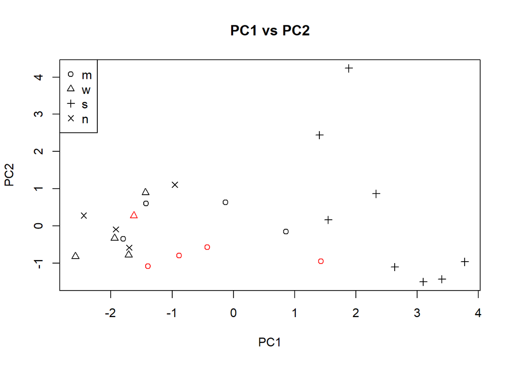

```r
scores <- data.frame(data_pca$x)
plot(scores$PC1, scores$PC2,
     pch = ifelse(compass == "m", 1,
                  ifelse (compass == "w", 2,
                          ifelse (compass == "s", 3, 4))),
     col = ifelse(lw == "l", 2,1),
     xlab = "PC1", ylab = "PC2", main = "PC1 vs PC2")
legend("topleft", legend = c("m", "w", "s", "n"), pch = c(1, 2, 3 , 4))
```

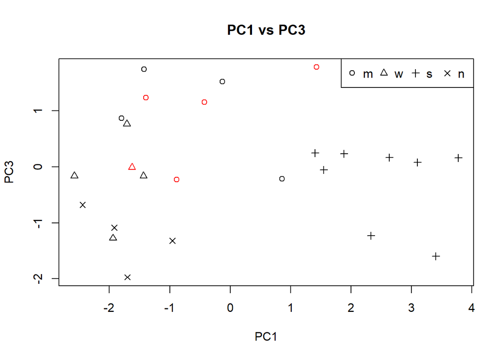

```r
plot(scores$PC1, scores$PC3,
     pch = ifelse(compass == "m", 1,
                  ifelse (compass == "w", 2,
                          ifelse (compass == "s", 3, 4))),
     col = ifelse(lw == "l", 2,1),
     xlab = "PC1", ylab = "PC3", main = "PC1 vs PC3")
legend("topright", legend = c("m", "w", "s", "n"), pch = c(1, 2, 3 , 4), horiz = T)
```

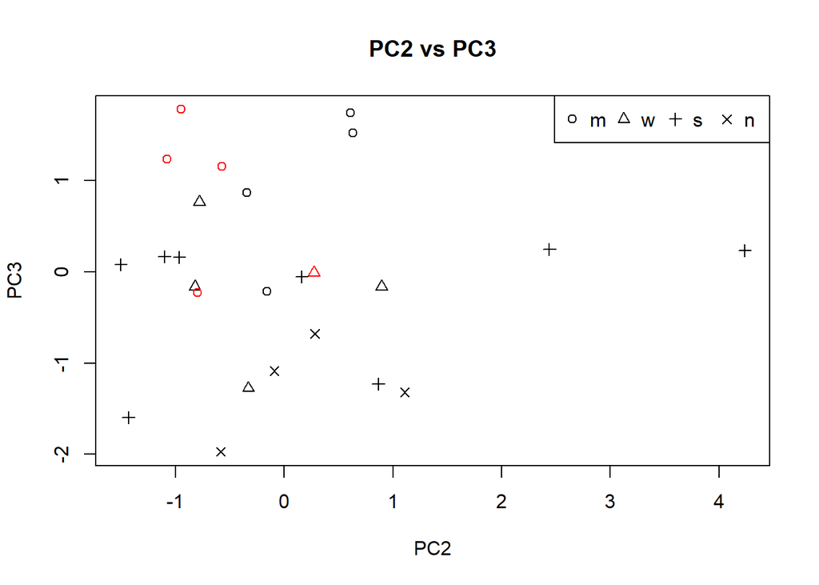

```r
plot(scores$PC2, scores$PC3,
     pch = ifelse(compass == "m", 1,
                  ifelse (compass == "w", 2,
                          ifelse (compass == "s", 3, 4))),
     col = ifelse(lw == "l", 2,1),
     xlab = "PC2", ylab = "PC3", main = "PC2 vs PC3")
legend("topright", legend = c("m", "w", "s", "n"), pch = c(1, 2, 3 , 4), horiz = T)
```

- 내륙과 바다에 대해서(빨간색: 내륙, 검정색: 바다와 인접)  
  그래프를 확인하면 내륙과 바다를 인접한 곳과 차이가 있는 것을 확인할 수 없습니다. 도움이 되진 않습니다.
- PC1관점  
  PC1에서 바라봤을 때, 남부나 중부는 비교적 구분이 잘 됬습니다만, 북부와 서부가 잘 비교가 되지 않습니다.

```r
index <- (compass == "n" | compass == "w")
t.test(scores$PC1[index] ~ compass[index], data = scores)
```

```
##
##  Welch Two Sample t-test
##
## data:  scores$PC1[index] by compass[index]
## t = 0.2842, df = 5.3072, p-value = 0.787
## alternative hypothesis: true difference in means is not equal to 0
## 95 percent confidence interval:
##  -0.8209406  1.0290420
## sample estimates:
## mean in group n mean in group w
##       -1.754916       -1.858967
```

t-test에서도 차이가 없다는 것을 확인할 수 있습니다.

순서 : s m (n = w), 내림차순

- PC2 관점  
  PC2에서 바라봤을 때, 남부 지방에서 약간 미미하게 차이나고, 대부분은 비슷합니다.

```r
aggregate(scores$PC2, by = list(compass), mean)
```

```
##   Group.1          x
## 1       m -0.3329120
## 2       n  0.1801362
## 3       s  0.3377739
## 4       w -0.1518880
```

```r
pairwise.t.test(scores$PC2, compass, p.adjust = "none", pool.sd = T)
```

```
##
##  Pairwise comparisons using t tests with pooled SD
##
## data:  scores$PC2 and compass
##
##   m    n    s
## n 0.53 -    -
## s 0.32 0.85 -
## w 0.81 0.71 0.52
##
## P value adjustment method: none
```

compass에 따른 PC2의 크기는 s > n > w > m 이지만,  
피셔의 최소유의차검정(LSD)에 따르면 차이가 없는 것으로 확인됩니다. 순서 : s = n = w = m, 내림차순

```r
aggregate(scores$PC3, by = list(compass), mean)
```

```
##   Group.1          x
## 1       m  0.9842544
## 2       n -1.2638178
## 3       s -0.2472975
## 4       w -0.1680768
```

```r
pairwise.t.test(scores$PC3, compass, p.adjust = "none", pool.sd = T)
```

```
##
##  Pairwise comparisons using t tests with pooled SD
##
## data:  scores$PC3 and compass
##
##   m       n     s
## n 5.9e-05 -     -
## s 0.003   0.034 -
## w 0.012   0.037 0.851
##
## P value adjustment method: none
```

차이가 어느정도 존재

순서 : m > w = s > n, 내림차순

## 결론

주성분 분석을 행한 결과, 곡식 등 땅에서 자라는 것은 compass(동서남북)에 따라서 차이있고, 조류 섭취에서도 어느정도의 차이가 있다, 다른 항목에서는 눈에 띄는 차이가  
없는 것으로 생각된다. 그리고 바다를 접하는지의 여부에 따라서의 차이는 없었다.

## 생각

새로운 범주를 만들어서 분석에 사용해도 되는지는 문제가 될 수 있지만 효율적인 방법이라고 생각했습니다. 국가와 국가끼리 비교하는 것은  
너무 경우의 수가 많다고 생각합니다.

만약 GDP가 있었다면 좀 더 흥미로운 분석이 될 수 있을 것이라는 생각이 듭니다.